# Hướng dẫn tạo bảng xếp hạng trong R

Duc Nguyen | Chuyên đào tạo kỹ năng R | `www.tuhocr.com`

Mar 16, 2023

**Các bạn sử dụng package FAOSTAT để download dataset về và subset ra dữ liệu về lúa gạo. Ở đây mình đã làm công đoạn cleaning data nên chỉ cần import vào để đưa code xuất ra bảng xếp hạng.**

```r
library(kableExtra)
library(formattable)
load("top20_rice.Rdata")
# options(width = 200)

top20_rice -> rice_topten

rice_compare <- subset(rice_topten, year == 2020 | year == 2000)

rice_compare
```

```
##                                        area item year production area_harvested
## 694                              Bangladesh Rice 2020   54905891       11417745
## 754                              Bangladesh Rice 2000   37627500       10801214
## 1382                                 Brazil Rice 2020   11091011        1677705
## 1442                                 Brazil Rice 2000   11134588        3664804
## 2062                               Cambodia Rice 2020   11248000        3322800
## 2110                               Cambodia Rice 2000    4026092        1903159
## 2995                        China, mainland Rice 2020  211860000       30080000
## 3055                        China, mainland Rice 2000  187908000       29961890
## 3817  Democratic People's Republic of Korea Rice 2020    2113019         470295
## 3873  Democratic People's Republic of Korea Rice 2000    1690000         535000
## 4346                                  Egypt Rice 2020    4804000         499361
## 4406                                  Egypt Rice 2000    6000490         659217
## 6417                                  India Rice 2020  186500000       45070000
## 6477                                  India Rice 2000  127464896       44712000
```

[output cut: 26 more lines]

```r
row.names(rice_compare) <- NULL

rice_compare <- rice_compare[- c(2)]

rice_compare$yield <- round(rice_compare$production / rice_compare$area_harvested,
                            digits = 2)

rice_compare$production <- round(rice_compare$production / 1000,
                            digits = 0)

rice_compare$area_harvested <- round(rice_compare$area_harvested / 1000,
                                 digits = 0)

rice_wide <- reshape(data = rice_compare,
                     idvar = c("area"),
                     # v.names = c("production"),
                     timevar = "year",
                     direction = "wide")


rice_wide <- rice_wide[c(1, 5, 2, 6, 3, 7, 4)]

rice_wide$percent_1 <- round(100 * (rice_wide$production.2020 - rice_wide$production.2000) / rice_wide$production.2000, digits = 2)

rice_wide$percent_2 <- round(100 * (rice_wide$area_harvested.2020 - rice_wide$area_harvested.2000) / rice_wide$area_harvested.2000, digits = 2)

rice_wide$percent_3 <- round(100 * (rice_wide$yield.2020 - rice_wide$yield.2000) / rice_wide$yield.2000, digits = 2)

rice_wide <- rice_wide[c(1, 2, 3, 8, 4, 5, 9, 6, 7, 10)]

rank_1 <- order(rice_wide$production.2020, decreasing = TRUE)

rice_wide <- rice_wide[rank_1, ]

row.names(rice_wide) <- NULL

rice_wide -> rice_wide_ok

rice_wide_ok -> rice_wide

###

rice_wide$production.2020 <- color_bar("lightgreen")(rice_wide$production.2020)
rice_wide$production.2000 <- color_bar("lightgreen")(rice_wide$production.2000)

rice_wide$area_harvested.2020 <- color_bar("orange")(rice_wide$area_harvested.2020)
rice_wide$area_harvested.2000 <- color_bar("orange")(rice_wide$area_harvested.2000)

rice_wide$yield.2020 <- color_bar("pink")(rice_wide$yield.2020)
rice_wide$yield.2000 <- color_bar("pink")(rice_wide$yield.2000)

rice_wide$percent_1 <- color_tile("white", "lightgreen")(rice_wide$percent_1)

rice_wide$percent_2 <- color_tile("white", "orange")(rice_wide$percent_2)

rice_wide$percent_3 <- color_tile("white", "pink")(rice_wide$percent_3)

file_image <- list.files("E:\\GITHUB\\project-neo\\r\\faostat\\png", full.names = TRUE)

gsub(".png", "", basename(file_image))[order(match(gsub(".png", "", basename(file_image)),
                                                   rice_wide$area))] -> file_image_2

file_image_3 <- paste0("png/", file_image_2, ".png")

rice_wide$rank <- 1:20

rice_wide$flag <- ""

rice_wide[c(11, 1, 2:10)] -> rice_wide

# rice_wide[c(12, 1:11)] -> rice_wide

names(rice_wide) <- c("Xếp hạng", "Quốc gia", "Năm 2000", "Năm 2020", "Tỷ lệ \ntăng trưởng (%)",
                      "Năm 2000", "Năm 2020", "Tỷ lệ \ntăng trưởng  (%)",
                      "Năm 2000", "Năm 2020", "Tỷ lệ \ntăng trưởng  (%)")

colnames(rice_wide) <- stringr::str_replace_all(colnames(rice_wide), "\\n", "<br>")

kbl(rice_wide, escape = FALSE, caption = "<center><strong><span style='color: blue'> Top 20 quốc gia sản xuất lúa gạo trên thế giới | Dữ liệu FAOSTAT | Minh họa: tuhocr.com</span></strong></center>",
    format = "html") %>%
  kable_styling(bootstrap_options = c("striped", "hover", "condensed", "responsive",
                                      position = "float_left")) %>%
  # kbl(caption = "Recreating booktabs style table") %>%
  kable_classic(full_width = F, html_font = "arial") %>%
  # kable_paper("hover", full_width = TRUE) %>%
  column_spec(1, width = "2cm") %>%
  column_spec(2, width = "8cm", border_right = TRUE) %>%
  column_spec(5, border_right = TRUE) %>%
  column_spec(8, border_right = TRUE) %>%
  column_spec(1, image = spec_image(file_image_3 , 96, 72)) %>%
  row_spec(0:20, bold = TRUE) %>%
  row_spec(5, background = "yellow") %>%
  add_header_above(c("", "", "Sản lượng thu hoạch (nghìn tấn)" = 3, "Diện tích canh tác (nghìn ha)" = 3, "Năng suất (tấn/ha)" = 3),
                   bold = TRUE)
```

**Top 20 quốc gia sản xuất lúa gạo trên thế giới | Dữ liệu FAOSTAT | Minh họa: tuhocr.com**

Sản lượng thu hoạch (nghìn tấn)

Diện tích canh tác (nghìn ha)

Năng suất (tấn/ha)

Xếp hạng

Quốc gia

Năm 2000

Năm 2020

Tỷ lệ  
tăng trưởng (%)

Năm 2000

Năm 2020

Tỷ lệ  
tăng trưởng (%)

Năm 2000

Năm 2020

Tỷ lệ  
tăng trưởng (%)

1

[figure not shown]

China, mainland

187908

211860

12.75

29962

30080

0.39

6.27

7.04

12.28

2

[figure not shown]

India

127465

186500

46.31

44712

45070

0.80

2.85

4.14

45.26

3

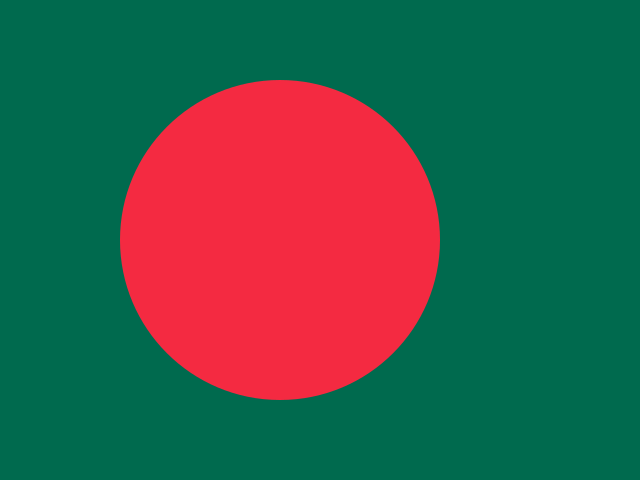

Bangladesh

37628

54906

45.92

10801

11418

5.71

3.48

4.81

38.22

4

[figure not shown]

Indonesia

51898

54649

5.30

11793

10657

-9.63

4.40

5.13

16.59

5

[figure not shown]

Viet Nam

32530

42765

31.46

7666

7222

-5.79

4.24

5.92

39.62

6

[figure not shown]

Thailand

25844

30231

16.97

9891

10402

5.17

2.61

2.91

11.49

7

[figure not shown]

Myanmar

20987

25983

23.81

6302

6830

8.38

3.33

3.80

14.11

8

[figure not shown]

Philippines

12389

19295

55.74

4038

4719

16.86

3.07

4.09

33.22

9

[figure not shown]

Pakistan

7204

12630

75.32

2377

3335

40.30

3.03

3.79

25.08

10

[figure not shown]

Cambodia

4026

11248

179.38

1903

3323

74.62

2.12

3.39

59.91

11

[figure not shown]

Brazil

11135

11091

-0.40

3665

1678

-54.22

3.04

6.61

117.43

12

[figure not shown]

Japan

11863

10469

-11.75

1770

1462

-17.40

6.70

7.16

6.87

13

[figure not shown]

United States of America

8658

10320

19.20

1230

1208

-1.79

7.04

8.54

21.31

14

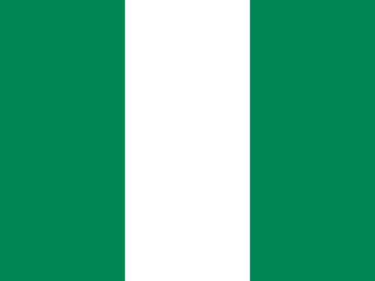

Nigeria

3298

8172

147.79

2199

4195

90.77

1.50

1.95

30.00

15

[figure not shown]

Nepal

4216

5551

31.67

1560

1459

-6.47

2.70

3.80

40.74

16

[figure not shown]

Sri Lanka

2860

5121

79.06

832

1066

28.12

3.44

4.80

39.53

17

[figure not shown]

Egypt

6000

4804

-19.93

659

499

-24.28

9.10

9.62

5.71

18

[figure not shown]

Republic of Korea

7197

4713

-34.51

1072

726

-32.28

6.71

6.49

-3.28

19

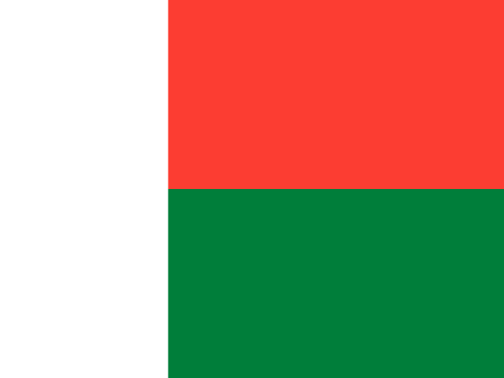

Madagascar

2480

4228

70.48

1209

1675

38.54

2.05

2.52

22.93

20

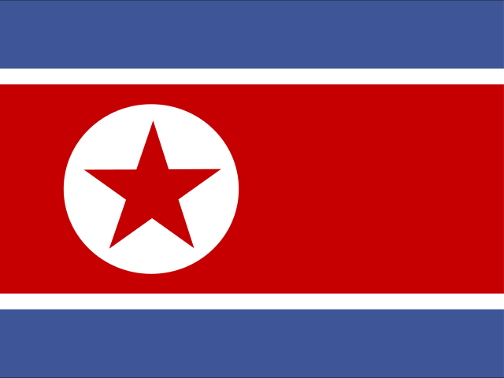

Democratic People’s Republic of Korea

1690

2113

25.03

535

470

-12.15

3.16

4.49

42.09

### Tài liệu tham khảo

1. `https://www.fao.org/faostat/en/#data`
2. `https://cran.r-project.org/web/packages/kableExtra/vignettes/awesome_table_in_html.html`
3. `https://svgtopng.com/`

### **Sơ kết**

Trên đây là hướng dẫn tạo bảng xếp hạng trong R. Để học R bài bản từ A đến Z, thân mời Bạn tham gia **khóa học “HDSD R để xử lý dữ liệu”** **để có nền tảng vững chắc về R nhằm tự tay làm các câu chuyện dữ liệu của riêng mình!**

**ĐĂNG KÝ NGAY: `https://www.tuhocr.com/register`**

**Hướng dẫn cài đặt package `tuhocr` `https://tuhocr.github.io/`**

[figure not shown]